# İstikrarlı Büyüme için Ekonomi Politikası Tasarımı

Erol Taymaz  
İktisat Bölümü  
Orta Doğu Teknik Üniversitesi  
http://users.metu.edu.tr/etaymaz

**Merih Celasun’a Saygı Günü**  
Tepav ⚫ İstanbul / 1 Aralık 2018

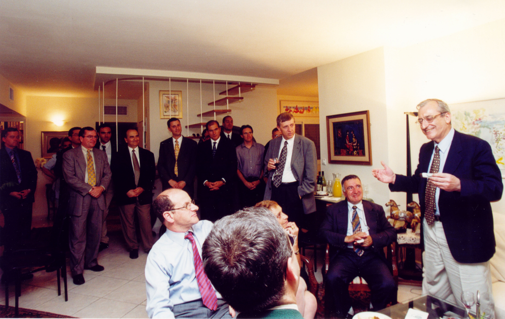

*Merih Celasun’un anısına saygıyla…*

# Ekonomik büyümü ve ekonomik istikrar

- İstikarsızlık büyümeyi engelliyor
  - Kısa döneme vurgu (uzun dönemli yatırımlar duruyor)
  - Rant arama (konut “yatırım”ı - konut fiyatının artması - kısır döngü)
  - İşten çıkarma ve iflaslar (bilgi birikimi kayboluyor)

# Ekonomik büyümü ve ekonomik istikrar

- Büyüme istikrar getiriyor
  - Büyümenin hızı
  - Büyümenin yönü/yapısı
  - Büyümenin finansmanı
  - Büyümenin paylaşımı

# Türkiye ekonomisi ve krizler

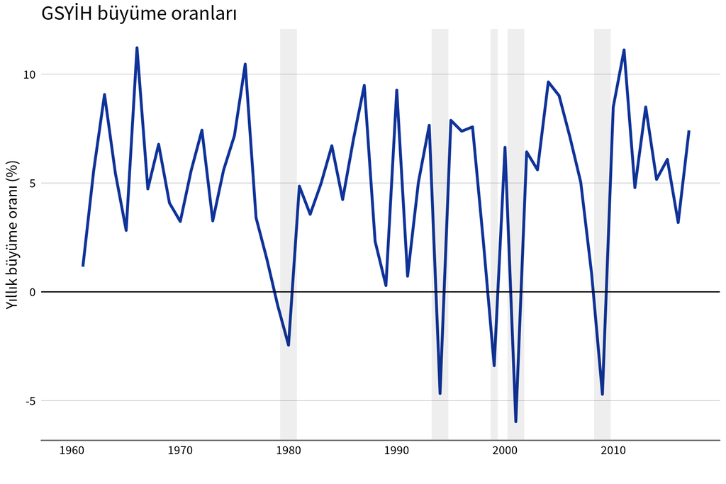

# Türkiye ekonomisi ve krizler

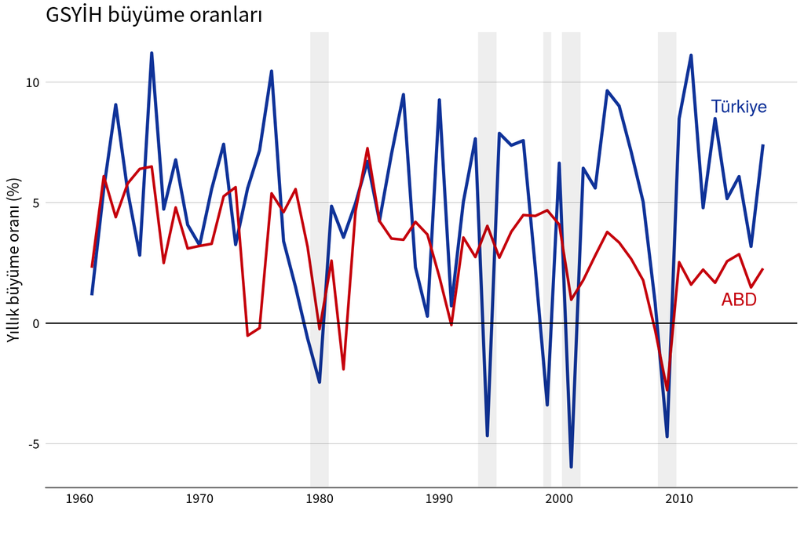

# Türkiye ekonomisi

- Büyümenin hızı
  - Uzun dönemli büyüme hızı oldukça istikrarlı
  - Büyüme hızı çok yüksek değil
  - Büyüme büyük ölçüde yatırımlara dayalı (TFP katkısı düşük)
    - Yatırım oranları düşük
    - Yatırımların önemli bir kısmı üretken yatırım değil (özellikle konut yatırımları)
- Büyümenin yönü/yapısı
  - Sanayinin payı düşük
  - Sanayinin yapısı - emek yoğun ve orta teknoloji sektörleri ağırlıklı
- Büyümenin finansmanı
  - Cari açık (borçlanma ve kamusal varlıkların satışı)
    - Yüksek risk (sermaye hareketlerine bağımlı büyüme)
    - TL’nin değerlenmesi (ihracata ve sanayinin gelişmesine olumsuz etki)
- Büyümenin paylaşımı
  - Gelir dağılımı eşitsiz
  - Servet dağılımı?
    - Vergi politikaları

# Türkiye ekonomisi

Büyümenin paylaşımı

↓

Büyümenin finansmanı

↓

Büyümenin yönü/yapısı

↓

Büyümenin hızı

# Ekonomi politikası tasarımı

- Kapsayıcı ve sürdürülebilir büyüme
  - “Dijital dönüşüm”
- Kurumsal yapı
  - Kalkınmacı, öğrenen devlet

# Kısıtlar: Dünya ekonomisi

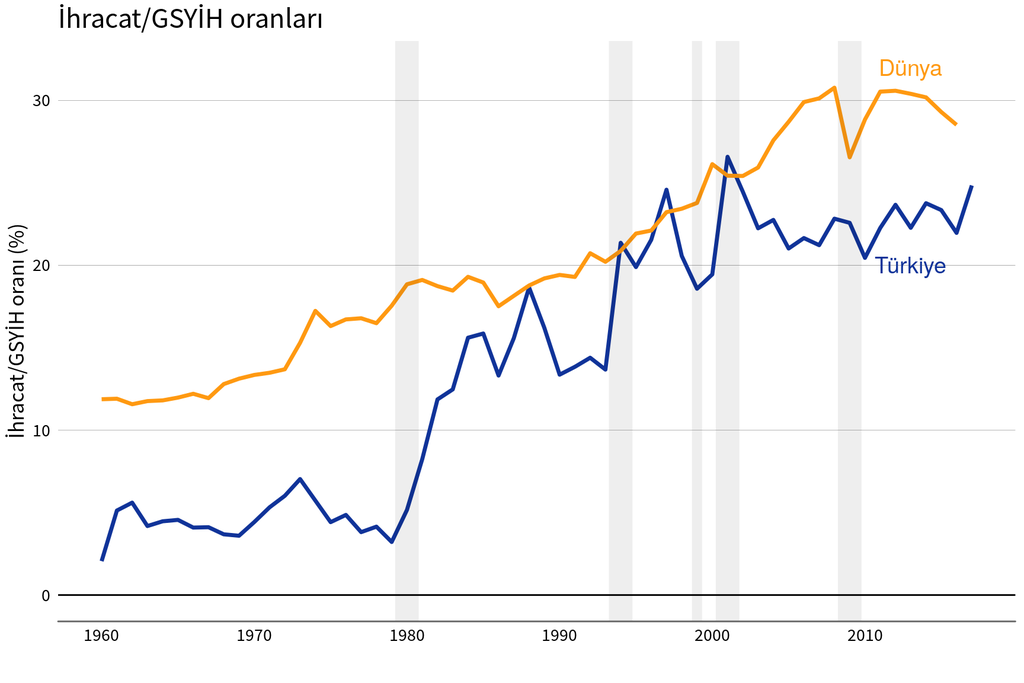

# Kısıtlar: Uluslararası ekonomi ile eklemlenme tarzı

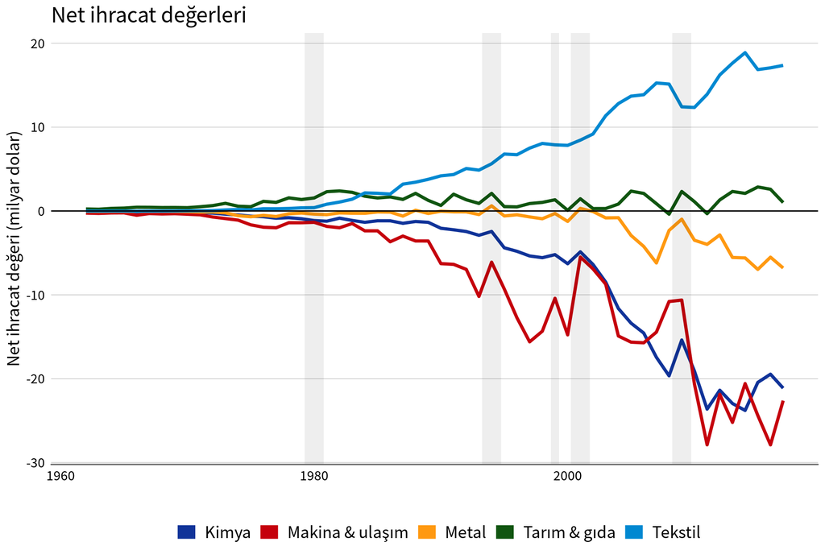

# Kısıtlar: Sermaye üretkenliği

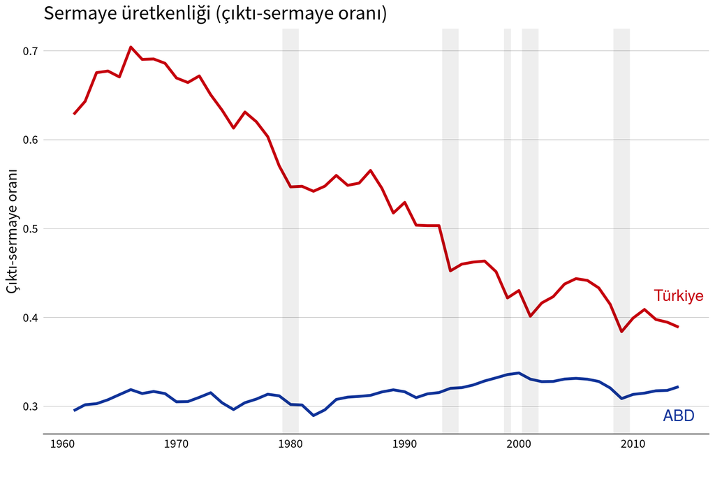

# Kısıtlar: Cari açık

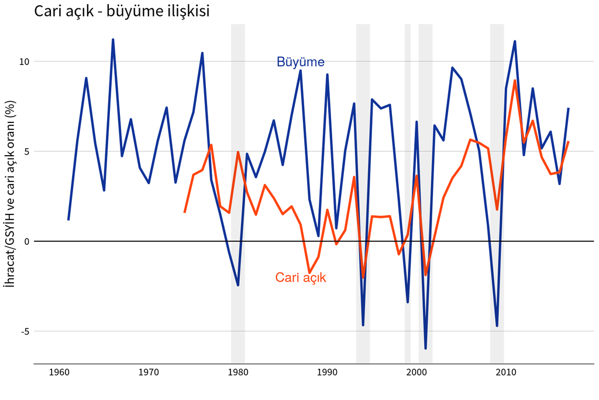

# Son söz yerine

“the Turkish economy still lacks a well-founded ‘debt strategy.’ Ever since the mid-1970s, the debt accumulation process has been marked by recourse to rather exotic arrangements whose long-term stability is problematic.” (Celasun and Rodrik, 1989)

Teşekkürler…

**Kaynaklar**

Celasun, M. ve Rodrik, D. (1989), “Turkish Experience with Debt: Macroeconomic Policy and Performance”, *Developing Country Debt and the World Economy*, der. J.D. Sachs, University of Chicago Press, 193-211.

Celasun, M. (2001), “Ekonomide Uzun Dönemli Büyüme, Enflasyon Süreci ve IMF Destekli Program”, *İkitsat, İşletme ve Finans* (16/179): 7-31.

Celasun, M. (2005), “Sürdürülebilir Yüksek Büyüme ve Makroekonomik İstikrar”, *İktisat, İşletme ve Finans* (20/226): 76-85.

World Bank, *World Development Indicators* (25 Kasım 2018)